# Statistical Analysis and Document Mining TP1

Elliott Perryman, Jan Zavadil, Ignat Sabaev

February 2022

## Part 1: Multiple regression on simulated data

### Spurious Correlations

With random number seed set to 0, random variables, samples are drawn from the standard normal. The variables are stored in an $N x M$ matrix, with N = 6,000 and M = 201. The random variables are not related at all, so a linear regression on the first column using the last 200 shows an intercept and slopes with a Gaussian distribution around 0. The equation and (truncated) output is shown below:
$$\hat{y_i} = \beta_0 + \sum^{200}_{i=1} \beta_i \epsilon_i \\
\epsilon_i \sim \mathcal{N}(0,I) \quad \forall i$$

```
##
## Call:
## lm(formula = X1 ~ ., data = data)
##
## Residuals:
##     Min      1Q  Median      3Q     Max
## -3.5630 -0.6506  0.0003  0.6708  3.0540
##
## Coefficients:
##               Estimate Std. Error t value Pr(>|t|)
## (Intercept)  1.209e-02  1.312e-02   0.921  0.35706
## X2          -2.276e-02  1.305e-02  -1.744  0.08122 .
## X3           5.220e-03  1.326e-02   0.394  0.69376
## X4           9.217e-03  1.307e-02   0.705  0.48081
## X5          -4.265e-03  1.294e-02  -0.330  0.74173
## X6           1.684e-02  1.311e-02   1.285  0.19892
## X7          -4.038e-03  1.294e-02  -0.312  0.75494
## X8           1.137e-02  1.312e-02   0.867  0.38622
## X9          -1.417e-02  1.335e-02  -1.062  0.28848
## X10         -3.186e-03  1.322e-02  -0.241  0.80953
##  [ reached getOption("max.print") -- omitted 191 rows ]
## ---
## Signif. codes:  0 '***' 0.001 '**' 0.01 '*' 0.05 '.' 0.1 ' ' 1
##
## Residual standard error: 0.999 on 5799 degrees of freedom
## Multiple R-squared:  0.03336,    Adjusted R-squared:  2.157e-05
## F-statistic: 1.001 on 200 and 5799 DF,  p-value: 0.4848
```

As shown in this output, the F statistic is close to 1, as expected, since the regression will not decrease the variance in the overall dataset. Since outputs with t values below X are read as “probability that the significance of this variable is due to random fluctuations is less than X percent”, roughly X*nrows will be reported as significant at the 5% level. This is shown below.

```r
sum(summary(fit)[["coefficients"]][, "Pr(>|t|)"]<0.05)
```

```
## [1] 9
```

```r
ncols * 0.05
```

```
## [1] 10.05
```

As seen above, 9 variables are read as significant at the 5% level. This is simply because there are so many explanatory variables, and it is clear from the fact that the F statistic is ~1 that there is no meaningful (mean) regression on these variables. The coefficients are themselves roughly normal random variables (shown below).

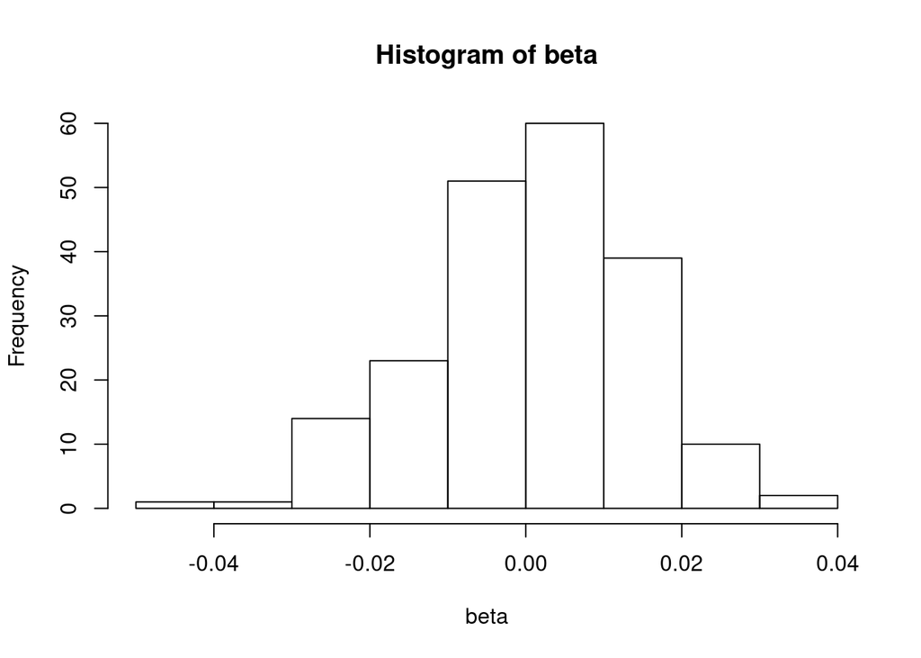

### Correlated Variables

#### Generation

Now the effects of correlated variables are investigated. for this example, the sample size is n=1,000 and samples for the following variables are given by:
$$X_{1,i} = \epsilon_{1,i} \\
X_{2,i} = 3*X_{1,i} + \epsilon_{2,i} \\
Y_i = X_{2,i} + X_{1,i} + 2 + \epsilon_{3,i} \\
\epsilon_{j,i} \sim \mathcal{N}(0,\sigma^2)$$
These variables are generated and plotted below.

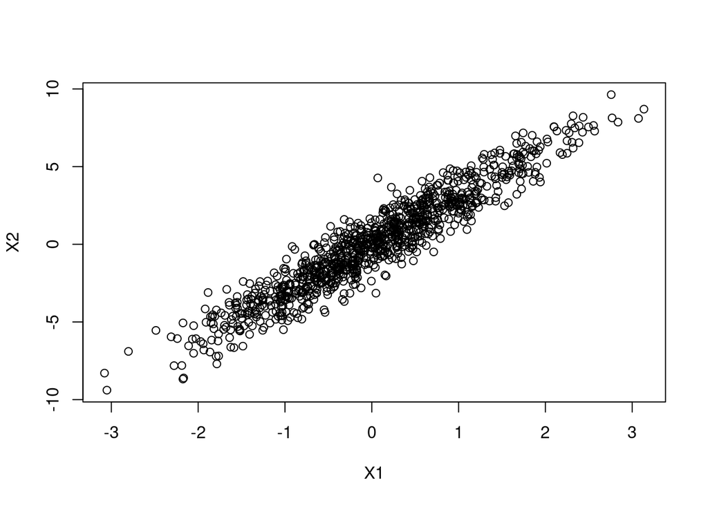

This plot shows the linear relationship between X1 and X2, the normal distribution of X1, and the normal distribution of X2 (expected by affine transformation of X1 and addition of normal variables). Linear regression gives the expected coefficients:

```
##
## Call:
## lm(formula = Y ~ X1 + X2, data = data)
##
## Residuals:
##     Min      1Q  Median      3Q     Max
## -4.2215 -0.6680  0.0320  0.6576  2.8570
##
## Coefficients:
##             Estimate Std. Error t value Pr(>|t|)
## (Intercept)  2.02016    0.03063   65.95   <2e-16 ***
## X1           1.10930    0.09639   11.51   <2e-16 ***
## X2           0.96875    0.03010   32.19   <2e-16 ***
## ---
## Signif. codes:  0 '***' 0.001 '**' 0.01 '*' 0.05 '.' 0.1 ' ' 1
##
## Residual standard error: 0.9682 on 997 degrees of freedom
## Multiple R-squared:  0.9494, Adjusted R-squared:  0.9493
## F-statistic:  9355 on 2 and 997 DF,  p-value: < 2.2e-16
```

Model 1: $Y_i = \beta_1 X_{1,i} + \beta_0 + \tilde{\epsilon}_{1,i}$

Model 2: $Y_i = \beta_2 X_{2,i} + \beta_0 + \tilde{\epsilon}_{2,i}$

In model 1, the two errors $\epsilon_1$ and $\epsilon_2$ are added together for a sigma of $\sqrt{2}$ (by square root of sum of $\sigma^2$). In model 1, the coefficient for X1 should be 4, since it is accounting for the X2 variable.

In model 2, the beta coefficient for X2 has an additional factor of $\frac{1}{3}$ from the X1 variable that is implicit in X1.

```
##
## Call:
## lm(formula = Y ~ X1, data = data.frame(X1, Y))
##
## Residuals:
##     Min      1Q  Median      3Q     Max
## -5.0203 -0.8801  0.0358  0.9690  4.4167
##
## Coefficients:
##             Estimate Std. Error t value Pr(>|t|)
## (Intercept)  2.01065    0.04371   45.99   <2e-16 ***
## X1           4.05262    0.04351   93.14   <2e-16 ***
## ---
## Signif. codes:  0 '***' 0.001 '**' 0.01 '*' 0.05 '.' 0.1 ' ' 1
##
## Residual standard error: 1.382 on 998 degrees of freedom
## Multiple R-squared:  0.8968, Adjusted R-squared:  0.8967
## F-statistic:  8676 on 1 and 998 DF,  p-value: < 2.2e-16
```

```
##
## Call:
## lm(formula = Y ~ X2, data = data.frame(X2, Y))
##
## Residuals:
##     Min      1Q  Median      3Q     Max
## -4.0205 -0.7049  0.0432  0.7061  2.9802
##
## Coefficients:
##             Estimate Std. Error t value Pr(>|t|)
## (Intercept)  2.02616    0.03258   62.19   <2e-16 ***
## X2           1.29734    0.01013  128.12   <2e-16 ***
## ---
## Signif. codes:  0 '***' 0.001 '**' 0.01 '*' 0.05 '.' 0.1 ' ' 1
##
## Residual standard error: 1.03 on 998 degrees of freedom
## Multiple R-squared:  0.9427, Adjusted R-squared:  0.9426
## F-statistic: 1.642e+04 on 1 and 998 DF,  p-value: < 2.2e-16
```

#### Restricted Regression with small N

Reseeding the random number generator to 3 and generating the same simulated output produces the following output. The estimates of all values have become significantly worse. Probably the estimates are much less reliable when the dealing with correlated variables and correlated noise. The same plots and regressions as above are repeated below.

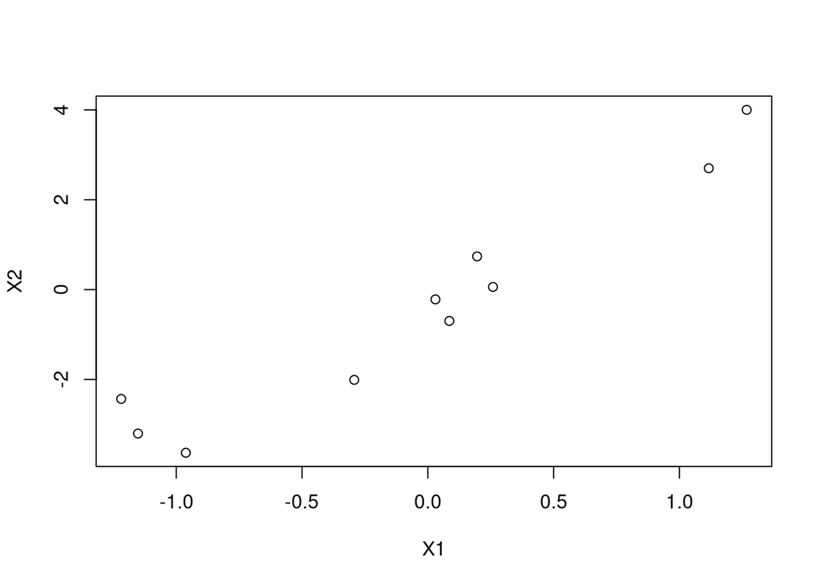

```
##
## Call:
## lm(formula = Y ~ X1 + X2, data = data)
##
## Residuals:
##      Min       1Q   Median       3Q      Max
## -0.99896 -0.66387 -0.09066  0.71179  1.30298
##
## Coefficients:
##             Estimate Std. Error t value Pr(>|t|)
## (Intercept)   1.5812     0.3234   4.890  0.00177 **
## X1            2.0628     1.2974   1.590  0.15588
## X2            0.7336     0.4519   1.623  0.14855
## ---
## Signif. codes:  0 '***' 0.001 '**' 0.01 '*' 0.05 '.' 0.1 ' ' 1
##
## Residual standard error: 0.9357 on 7 degrees of freedom
## Multiple R-squared:  0.9494, Adjusted R-squared:  0.9349
## F-statistic: 65.63 on 2 and 7 DF,  p-value: 2.92e-05
```

```
##
## Call:
## lm(formula = Y ~ X1, data = data.frame(X1, Y))
##
## Residuals:
##     Min      1Q  Median      3Q     Max
## -1.4216 -0.5664 -0.3675  0.6896  1.8840
##
## Coefficients:
##             Estimate Std. Error t value Pr(>|t|)
## (Intercept)   1.3733     0.3258   4.215  0.00294 **
## X1            4.0861     0.3954  10.334 6.64e-06 ***
## ---
## Signif. codes:  0 '***' 0.001 '**' 0.01 '*' 0.05 '.' 0.1 ' ' 1
##
## Residual standard error: 1.027 on 8 degrees of freedom
## Multiple R-squared:  0.9303, Adjusted R-squared:  0.9216
## F-statistic: 106.8 on 1 and 8 DF,  p-value: 6.637e-06
```

```
##
## Call:
## lm(formula = Y ~ X2, data = data.frame(X2, Y))
##
## Residuals:
##     Min      1Q  Median      3Q     Max
## -1.3320 -0.3809 -0.0879  0.2556  1.7751
##
## Coefficients:
##             Estimate Std. Error t value Pr(>|t|)
## (Intercept)   1.7662     0.3292   5.365 0.000674 ***
## X2            1.4239     0.1370  10.397 6.34e-06 ***
## ---
## Signif. codes:  0 '***' 0.001 '**' 0.01 '*' 0.05 '.' 0.1 ' ' 1
##
## Residual standard error: 1.021 on 8 degrees of freedom
## Multiple R-squared:  0.9311, Adjusted R-squared:  0.9225
## F-statistic: 108.1 on 1 and 8 DF,  p-value: 6.344e-06
```

## Part 2: Analysis of prostate cancer data

### 3. Best subset selection

#### a)

Three models are considered, each of which is very simple. Their descriptions and output are given below. First model is $lcavol = \beta_0 + \varepsilon$. It is a model of size O.

```
##
## Call:
## lm(formula = lcavol ~ 1, data = pro)
##
## Residuals:
##      Min       1Q   Median       3Q      Max
## -2.69708 -0.83719  0.09691  0.77703  2.47099
##
## Coefficients:
##             Estimate Std. Error t value Pr(>|t|)
## (Intercept)   1.3500     0.1197   11.28   <2e-16 ***
## ---
## Signif. codes:  0 '***' 0.001 '**' 0.01 '*' 0.05 '.' 0.1 ' ' 1
##
## Residual standard error: 1.179 on 96 degrees of freedom
```

```
## [1] "Residual sum of squares is 133.359033889223"
```

Following model is $lcavol = \beta_1 lbph + \beta_2 lpsa + \varepsilon$. It is a model of size 2.

```
##
## Call:
## lm(formula = lcavol ~ ., data = pro[, c(1, 4, 9)])
##
## Residuals:
##     Min      1Q  Median      3Q     Max
## -2.2998 -0.6245  0.0414  0.5564  1.6266
##
## Coefficients:
##             Estimate Std. Error t value Pr(>|t|)
## (Intercept) -0.54900    0.19459  -2.821  0.00583 **
## lbph        -0.08791    0.05709  -1.540  0.12697
## lpsa         0.76979    0.07176  10.728  < 2e-16 ***
## ---
## Signif. codes:  0 '***' 0.001 '**' 0.01 '*' 0.05 '.' 0.1 ' ' 1
##
## Residual standard error: 0.7983 on 94 degrees of freedom
## Multiple R-squared:  0.5508, Adjusted R-squared:  0.5412
## F-statistic: 57.62 on 2 and 94 DF,  p-value: < 2.2e-16
```

```
## [1] "Residual sum of squares is 59.9097892820639"
```

The last model is $lcavol = \beta_1 lweight + \beta_2 lpsa + \varepsilon$. It is a model of size 2.

```
##
## Call:
## lm(formula = lcavol ~ ., data = pro[, c(1, 2, 9)])
##
## Residuals:
##      Min       1Q   Median       3Q      Max
## -2.06980 -0.60231  0.05406  0.53762  1.70037
##
## Coefficients:
##             Estimate Std. Error t value Pr(>|t|)
## (Intercept) -0.09570    0.71596  -0.134    0.894
## lweight     -0.12781    0.21327  -0.599    0.550
## lpsa         0.77047    0.07915   9.734 6.75e-16 ***
## ---
## Signif. codes:  0 '***' 0.001 '**' 0.01 '*' 0.05 '.' 0.1 ' ' 1
##
## Residual standard error: 0.8068 on 94 degrees of freedom
## Multiple R-squared:  0.5412, Adjusted R-squared:  0.5314
## F-statistic: 55.44 on 2 and 94 DF,  p-value: < 2.2e-16
```

```
## [1] "Residual sum of squares is 61.1871213344348"
```

The lowest residual sum of squares, as well as the highest value of F-test, is observed with the second implemented model.

#### b)

```
## [1] " RSS for combination -  2 , 3  is  120.402501227025"
## [1] " RSS for combination -  2 , 4  is  121.31398244673"
## [1] " RSS for combination -  2 , 5  is  89.3452701547991"
## [1] " RSS for combination -  2 , 6  is  68.6076487865289"
## [1] " RSS for combination -  2 , 7  is  99.6599372602951"
## [1] " RSS for combination -  2 , 8  is  100.895025274654"
## [1] " RSS for combination -  2 , 9  is  61.1871213344348"
## [1] " RSS for combination -  3 , 4  is  126.205507884574"
## [1] " RSS for combination -  3 , 5  is  91.1061939836275"
## [1] " RSS for combination -  3 , 6  is  69.9302061444024"
## [1] " RSS for combination -  3 , 7  is  106.723592066783"
## [1] " RSS for combination -  3 , 8  is  106.680685657678"
## [1] " RSS for combination -  3 , 9  is  60.035696734806"
## [1] " RSS for combination -  4 , 5  is  93.9098332051736"
## [1] " RSS for combination -  4 , 6  is  72.4041932988172"
## [1] " RSS for combination -  4 , 7  is  108.417632986711"
## [1] " RSS for combination -  4 , 8  is  108.274319621022"
## [1] " RSS for combination -  4 , 9  is  59.9097892820639"
## [1] " RSS for combination -  5 , 6  is  70.8091732639893"
## [1] " RSS for combination -  5 , 7  is  84.6094196046381"
## [1] " RSS for combination -  5 , 8  is  88.7355809176743"
## [1] " RSS for combination -  5 , 9  is  58.4521881833056"
## [1] " RSS for combination -  6 , 7  is  71.2382091573899"
## [1] " RSS for combination -  6 , 8  is  72.5299945406043"
## [1] " RSS for combination -  6 , 9  is  47.2780972897865"
## [1] " RSS for combination -  7 , 8  is  104.809860064083"
## [1] " RSS for combination -  7 , 9  is  57.3988304284976"
## [1] " RSS for combination -  8 , 9  is  58.946249575393"
```

The lowest RSS (~47) is reached with combination of predictors 6 and 9 (lcp, lpsa).

#### c)

In the following code we compute the minimal RSS for each size of the model between 0 and 8. In the figure below, the minimal RSS is plotted against the size of model.

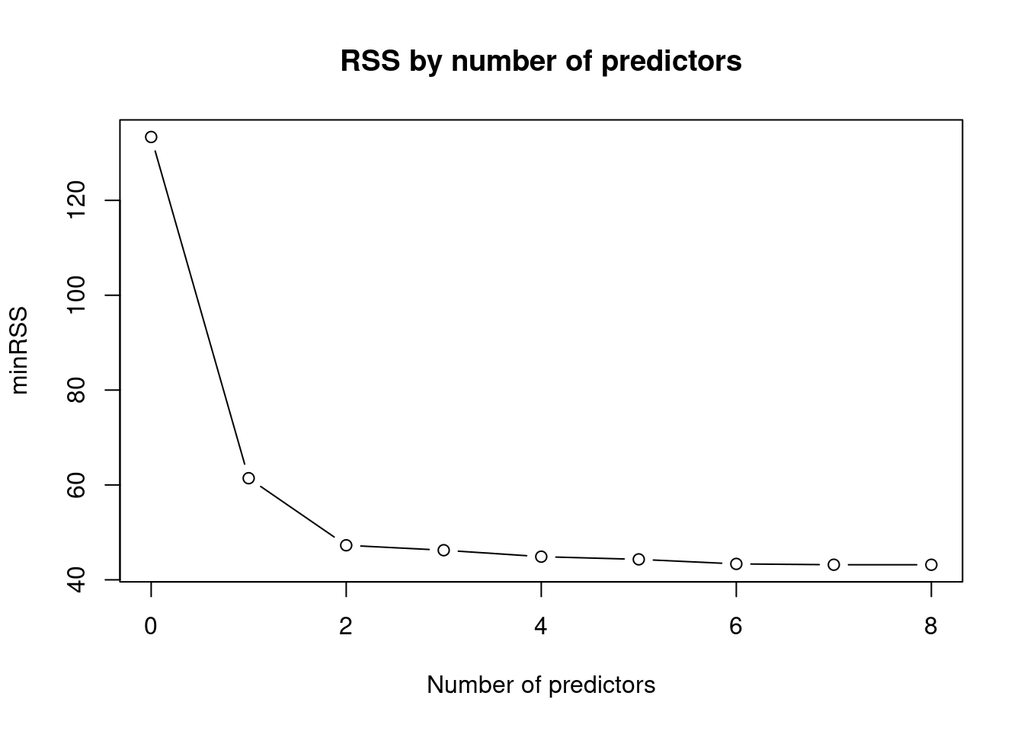

Further, we provide the list of predictors minimalizing the RSS for each size of the regression model.

```
## [1] "Number of predictors:  1 . Predictors minimalizing RSS:  9"
## [1] "Number of predictors:  2 . Predictors minimalizing RSS:  c(6, 9)"
## [1] "Number of predictors:  3 . Predictors minimalizing RSS:  c(3, 6, 9)"
## [1] "Number of predictors:  4 . Predictors minimalizing RSS:  c(3, 4, 6, 9)"
## [1] "Number of predictors:  5 . Predictors minimalizing RSS:  c(3, 4, 6, 8, 9)"
## [1] "Number of predictors:  6 . Predictors minimalizing RSS:  c(3, 4, 6, 7, 8, 9)"
## [1] "Number of predictors:  7 . Predictors minimalizing RSS:  c(3, 4, 5, 6, 7, 8, 9)"
## [1] "Number of predictors:  8 . Predictors minimalizing RSS:  c(2, 3, 4, 5, 6, 7, 8, 9)"
```

#### d)

We do not think that only minimizing the RSS is a good way to determine the optimal size of the regression model. That way, we would always chose the maximal size possible, as the RSS always decreases with higher size of model. It would be better to observe the decrease of RSS between each step up in size and once this difference is low enough (for example size = 2 in our case) we would call it the optimal size.

### 4. Split Validation

#### (a).

Split validation works by taking some representative (usually random) sample of the original dataset, and excluding those samples from the data used to fit models. After models {$M_0$, $M_1$, …} are fit, they are evaluated on the validation set. This tests the generalization power of the model. For example, maybe if the true underlying function has some corrupting noise, parametric regression would still have residual error on its training data. However, the model that just memorizes every training point and returns the previous y value if it has seen it before otherwise returning infinity would have 0 error on its training data. Cross validation like this punishes models for memorizing quirks in the training data, thus reducing the types of effects from section 3.

#### (b).

For the $M_2$ model, the features used are 6 and 9. Its regression and metric (variance of residuals) on the training data is given below.

```r
summary(fit)
```

```
##
## Call:
## lm(formula = lcavol ~ ., data = pro[!valid, c(1, 6, 9)])
##
## Residuals:
##      Min       1Q   Median       3Q      Max
## -1.11959 -0.57345 -0.08939  0.62260  1.97063
##
## Coefficients:
##             Estimate Std. Error t value Pr(>|t|)
## (Intercept) -0.10264    0.25189  -0.407   0.6851
## lcp          0.24836    0.07473   3.323   0.0015 **
## lpsa         0.60261    0.09289   6.488 1.64e-08 ***
## ---
## Signif. codes:  0 '***' 0.001 '**' 0.01 '*' 0.05 '.' 0.1 ' ' 1
##
## Residual standard error: 0.6957 on 62 degrees of freedom
## Multiple R-squared:  0.6682, Adjusted R-squared:  0.6575
## F-statistic: 62.43 on 2 and 62 DF,  p-value: 1.405e-15
```

```r
metric(fit)
```

```
## [1] 0.4688799
```

```r
metric(fit, validation = TRUE)
```

```
## [1] 0.5853993
```

This shows the summary of the $M_2$ model, along with its variance of residuals for training and validation data. Next, this process is repeated for all models to produce the figure below. This is also repeated for randomly selected validation data.

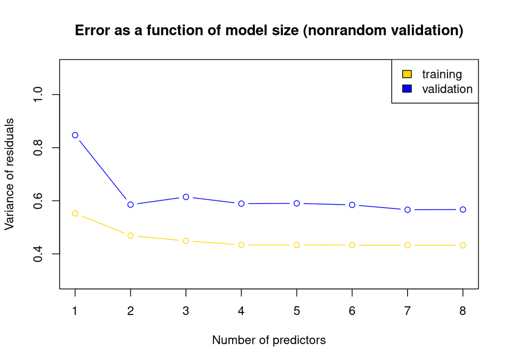

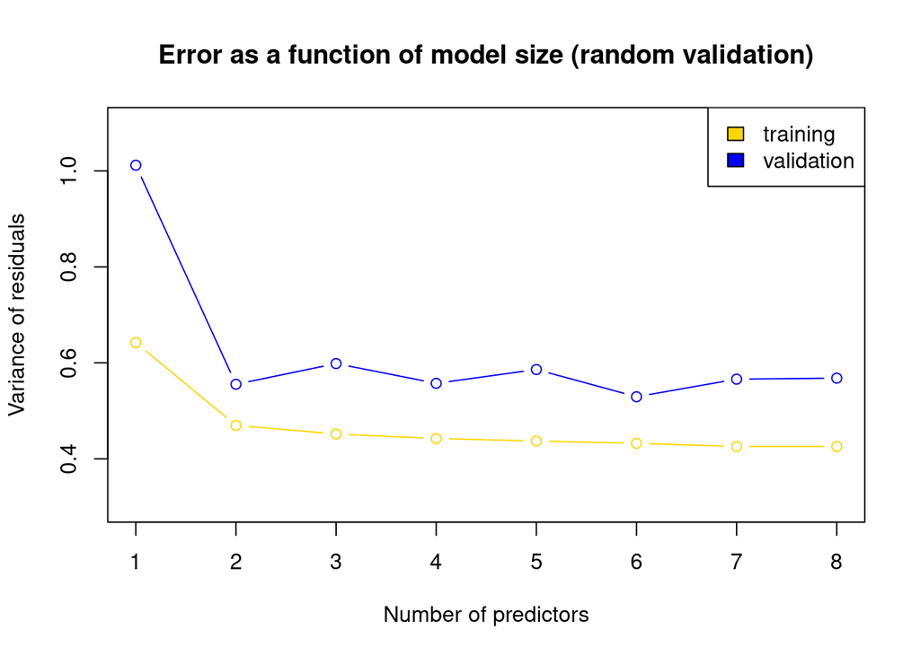

The main limitation of split validation is that it requires a representative sample of the data, which can cause the training data to be too small for a representative sample. Even if those are both true, it still trades accuracy in training for comparison, which is a non negligible drawback. This is seen by the two graphs above, which show how the difference in choice of validation can cause an interpretation difference.

From this figure, we conclude that the $M_2$ model is best. Our argument is as follows: in the absence of compelling explanatory power, choose the simplest model. Even though other models have low validation error, $M_2$ is the smallest model that could give near optimal power. This sort of “Occam’s Razor” approach has many benefits. For example, this would allow in-the-field domain experts to estimate lcavol directly via a simple formula that is easily interpretable. In addition, data collection is easier when there are far fewer measurements. Further research can dive into why one factor is so strongly correlated, rather than trying to pin down explanations between 7 variables.